# **PROSPER LOAN DATA ANALYSIS**

### by ASHI RIZVI

Prosper is a San Francisco,California based company in the peer to peer lending industry. With Prosper individuals can either invest in personal loans or request to borrow money.

Prosper Loan data set contains 113,937 rows and 81 columns. It contains detailed information(81 variables)about each loan listings from the year 2005 to 2014. The data from 2014 is only partial as it contains only first two months of listings.

I created a subset of this dataset by picking 33 variables to study and studied around 10 of them

```python
import pandas as pd
import datetime as dt
import numpy as np
import seaborn as sb
import matplotlib.pyplot as plt
%matplotlib inline
```

```python
loan_data=pd.read_csv('prosperLoanData.csv')
```

```python
loan_data.shape
```

```
(113937, 81)
```

```python
loan_data_subset1=loan_data[['ListingNumber','ListingKey', 'ListingCreationDate', 'CreditGrade',
       'Term', 'LoanStatus','BorrowerAPR', 'BorrowerRate',
       'LenderYield', 'EstimatedEffectiveYield','EstimatedLoss','EstimatedReturn','ProsperRating (numeric)', 'ProsperRating (Alpha)',
       'ProsperScore', 'ListingCategory (numeric)',
       'Occupation', 'EmploymentStatus','IsBorrowerHomeowner','OpenCreditLines',
              'BankcardUtilization','DebtToIncomeRatio',
       'PercentFunded','Recommendations',
        'InvestmentFromFriendsCount','InvestmentFromFriendsAmount','Investors',
        'IncomeRange','StatedMonthlyIncome','TotalProsperLoans','ProsperPrincipalBorrowed',
        'LoanOriginalAmount','MemberKey']]
```

```python
#make a copy of loan data subset
loan_data_subset1_copy=loan_data_subset1.copy()
loan_data_subset1_copy.shape
```

```
(113937, 33)
```

### What is the structure of your dataset?

> Prosper Loan data set data set contains 113,937 loan listings with 81 variables. The data from 2014 is only partial as it contains only first two months of listings. There was missing data in some columns like CreditGrade, Estimated Effective Yield,Prosper Rating,Prosper Score because of change in methodology in 2009. Data was also checked for any duplicates and cleaned for some data types.

**What is/are the main feature(s) of interest in your dataset?**

I noticed that in the data the ratings have been divided into two periods-pre 2009 and post 2009. A little research on the internet revealed that Prosper changed its methodology for calculating borrower's interest rate after 2009.

From 2006-2009 the interest rate for loan was determined by a Dutch auction like system,similar to ebay. Prosper later used its own algorithms to come up with a rate based on each borrower's credit rating.Under the new approach, lenders no longer determine the loan rate via price discovery in an auction. Instead, they simply choose whether or not to invest at the rate which Prosper's loan pricing algorithm assigns to the loan after it analyzes the borrower's credit report and financial information.

I want to study how the borrower interest rates have varied over the two periods ie., pre 2009 and post 2009.

I also want to study how credit ratings term and size of the loan affect the borrower's interest rate

**What features in the dataset do you think will help support your investigation into your feature(s) of interest?**

I think the rates before 2009 and after 2009 should have some difference because the methodology has changed entireley for determining borrower's rate. The data has already been divided into pre 2009 & post 2009 on the basis of 'CreditGrade' and 'ProsperRating(Alpha)'. I will study the avergae borrower rate for these two periods

I think bigger loans are more risky than smaller loans, so they should have on average higher interest rate than small loans and the interest rate should increase as the credit risk increases. For this I will study the different credit ratings and Loan Amount and see how they determine the borrower rate

**Cleaning The Data**

I will start by cleaning the data and checking if there are any duplicates in the data. I will also change the datatype wherever its needed.

```python
# convert CreditGrade, LoanStatus,ProsperRating (numeric),ProsperRating (Alpha)
#and ListingCategory (numeric) into ordered categorical types
ordinal_var_dict = {'CreditGrade': ['NC','HR','E','D','C','B','A','AA'],
                    'LoanStatus': ['Cancelled', 'Chargedoff', 'Completed', 'Current',
                                   'Defaulted', 'FinalPaymentInProgress',
                                   'Past Due (1-15 days)','Past Due (16-30 days)',
                                   'Past Due (31-60 days)',
                                   'Past Due (61-90 days)','Past Due (91-120 days)'],
                    'ProsperRating (numeric)' : [0,1,2,3,4,5,6,7],
                    'ProsperRating (Alpha)': ['HR','E','D','C','B','A','AA'],
                    'ListingCategory (numeric)': [0,1,2,3,4,5,6,7,8,9,10,11,12,13,14,15,16,17,18,19,20]}

for var in ordinal_var_dict:
    pd_ver = pd.__version__.split(".")
    if (int(pd_ver[0]) > 0) or (int(pd_ver[1]) >= 21): # v0.21 or later
        ordered_var = pd.api.types.CategoricalDtype(ordered = True,
                                                    categories = ordinal_var_dict[var])
        loan_data_subset1_copy[var] = loan_data_subset1_copy[var].astype(ordered_var)
    else: # pre-v0.21
        loan_data_subset1_copy[var] = loan_data_subset1_copy[var].astype('category', ordered = True,
                                             categories = ordinal_var_dict[var])
```

```python
#check for Listing key duplicates
listingkey_duplicates=loan_data_subset1_copy[loan_data_subset1_copy.ListingKey.duplicated()]
len(listingkey_duplicates)
```

```
871
```

```python
#set the color for all graphs
base_color=sb.color_palette()[2]
plt.figure(figsize=[14.70, 8.27])
```

```python
#Manually check duplicates
loan_data_subset1_copy[loan_data_subset1_copy.ListingKey=='0F043596202561788EA13D5']
loan_data_subset1_copy[loan_data_subset1_copy.ListingKey=='85B8359189827433103090E']
```

|  | ListingNumber | ListingKey | ListingCreationDate | CreditGrade | Term | LoanStatus | BorrowerAPR | BorrowerRate | LenderYield | EstimatedEffectiveYield | ... | Recommendations | InvestmentFromFriendsCount | InvestmentFromFriendsAmount | Investors | IncomeRange | StatedMonthlyIncome | TotalProsperLoans | ProsperPrincipalBorrowed | LoanOriginalAmount | MemberKey |
| --- | --- | --- | --- | --- | --- | --- | --- | --- | --- | --- | --- | --- | --- | --- | --- | --- | --- | --- | --- | --- | --- |
| 33314 | 959620 | 85B8359189827433103090E | 2013-10-25 11:28:26.710000000 | NaN | 36 | Current | 0.11563 | 0.0879 | 0.0779 | 0.07582 | ... | 0 | 0 | 0.0 | 1 | $75,000-99,999 | 7500.0 | NaN | NaN | 13000 | 08623587348596410853DFB |
| 110523 | 959620 | 85B8359189827433103090E | 2013-10-25 11:28:26.710000000 | NaN | 36 | Current | 0.11563 | 0.0879 | 0.0779 | 0.07582 | ... | 0 | 0 | 0.0 | 1 | $75,000-99,999 | 7500.0 | NaN | NaN | 13000 | 08623587348596410853DFB |
| 111850 | 959620 | 85B8359189827433103090E | 2013-10-25 11:28:26.710000000 | NaN | 36 | Current | 0.11563 | 0.0879 | 0.0779 | 0.07582 | ... | 0 | 0 | 0.0 | 1 | $75,000-99,999 | 7500.0 | NaN | NaN | 13000 | 08623587348596410853DFB |

3 rows × 33 columns

```python
#clean the data by removing listing key duplicates
loan_data_subset1_copy.drop_duplicates(subset=['ListingKey'], keep='first',inplace=True)
```

```python
#test if all the duplicates have been removed
sum(loan_data_subset1_copy.ListingKey.duplicated())
```

```
0
```

```python
#change the datatype of listing date to datetime
loan_data_subset1_copy['ListingCreationDate']=pd.to_datetime(loan_data_subset1_copy['ListingCreationDate'])
```

```python
#extract the year out of the timestamp
loan_data_subset1_copy['Loan_Date']=loan_data_subset1_copy['ListingCreationDate'].dt.date
```

```python
#change the loan year to datetime
loan_data_subset1_copy['Loan_Date']=pd.to_datetime(loan_data_subset1_copy['Loan_Date'])
```

```python
#extract only the year from loan date
loan_data_subset1_copy['Loan_Year']=loan_data_subset1_copy['Loan_Date'].dt.year
```

```python
#chaeck it from a sample
loan_data_subset1_copy.sample(2)
```

|  | ListingNumber | ListingKey | ListingCreationDate | CreditGrade | Term | LoanStatus | BorrowerAPR | BorrowerRate | LenderYield | EstimatedEffectiveYield | ... | InvestmentFromFriendsAmount | Investors | IncomeRange | StatedMonthlyIncome | TotalProsperLoans | ProsperPrincipalBorrowed | LoanOriginalAmount | MemberKey | Loan_Date | Loan_Year |
| --- | --- | --- | --- | --- | --- | --- | --- | --- | --- | --- | --- | --- | --- | --- | --- | --- | --- | --- | --- | --- | --- |
| 17398 | 501742 | 420B3511663651047D84318 | 2011-04-11 11:50:40.757 | NaN | 36 | Current | 0.29510 | 0.2599 | 0.2499 | 0.2437 | ... | 0.0 | 28 | $1-24,999 | 1000.0 | NaN | NaN | 3500 | 3AD735125635764117A05E8 | 2011-04-11 | 2011 |
| 35366 | 21868 | E8B433658820380236C7319 | 2006-06-27 16:59:45.283 | HR | 36 | Defaulted | 0.29525 | 0.2875 | 0.2700 | NaN | ... | 0.0 | 24 | Not displayed | 4000.0 | NaN | NaN | 2550 | B4E03364681565421C2FBF4 | 2006-06-27 | 2006 |

2 rows × 35 columns

## Univariate Exploration

**Points to Explore in Univariate Distributions**

- Distribution of Loan status
- No of loans in each credit rating category
- Borrower APR/ Borrower Interest Rate
- Distribution of Estimated Return
- distribution of loan size
- Debt to Income Ratio distribution
1. Distribution of Loan Amounts

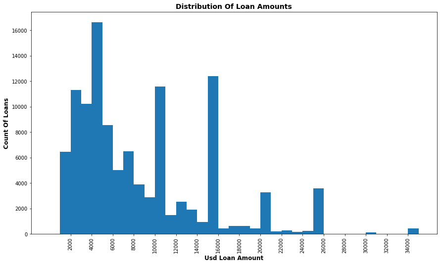

```python
#distribution of loan size
plt.figure(figsize=[14.70, 8.27]);
bin_loan=np.arange(0,36000,1000)
plt.hist(x=loan_data_subset1_copy['LoanOriginalAmount'],
             bins=bin_loan);
ticks=[2000,4000,6000,8000,10000,12000,14000,16000,18000,20000,22000,24000,26000,28000,30000,32000,34000]
plt.xticks(ticks,rotation=90);
plt.xlabel('USD Loan Amount'.title(),
               fontsize = 12, weight = "bold");
plt.ylabel('Count of Loans'.title(),
               fontsize = 12, weight = "bold");
plt.title('Distribution of Loan Amounts'.title(),
               fontsize = 14, weight = "bold");
```

Conclusion: Many loans are of size less than 5000.Very few loans above 25000. Most popular loan amounts are in multiples of 5k like 10,15k,20k,25k; thats where we see spikes in the distribution. Loans more than 30000 are very few

1. Distribution of Estimated Returns and BorrowerAPR

```python
loan_data_subset1_copy['EstimatedReturn_in_perct']=loan_data_subset1_copy['EstimatedReturn']*100
loan_data_subset1_copy['EstimatedReturn_in_perct'].describe()
df_est_return=loan_data_subset1_copy['EstimatedReturn_in_perct'].dropna()
df_est_return=df_est_return.reset_index(name='estimated_return')
```

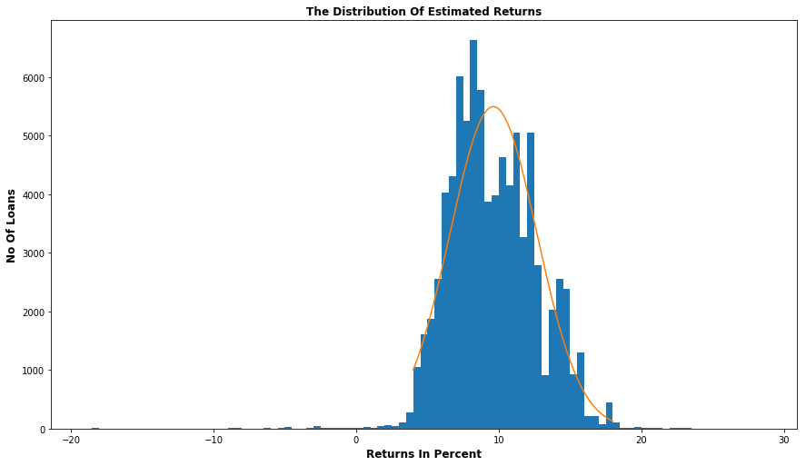

```python
# Show how Returns are normally distributed
plt.figure(figsize=[14.70, 8.27]);

bin_size=0.5
bin_edges = np.arange(-19, 29,0.5)
plt.hist(data = df_est_return, x = 'estimated_return', bins = bin_edges);

# overlay a theoretical normal distribution on top
samp_mean = df_est_return['estimated_return'].mean()
samp_sd = df_est_return['estimated_return'].std()

from scipy.stats import norm
x = np.linspace(4, 18, 200)
y = norm.pdf(x, samp_mean, samp_sd) # normal distribution heights
y *= df_est_return.shape[0] * bin_size # scale the distribution height

plt.plot(x, y);
plt.title('The distribution of Estimated Returns'.title(),
               fontsize = 12, weight = "bold")
plt.xlabel('Returns in percent'.title(),
               fontsize = 12, weight = "bold")
plt.ylabel('No of loans'.title(),
               fontsize = 12, weight = "bold");
```

Conclusion: Estimated Returns range from -18 to 28%. The returns follow a normal distribution with mean returns around 10% and standard deviation of 3%

```python
#Remove the nulls in BorrowerAPR
non_null_BorrowerAPR=loan_data_subset1_copy[loan_data_subset1_copy['BorrowerAPR'].notnull()]
```

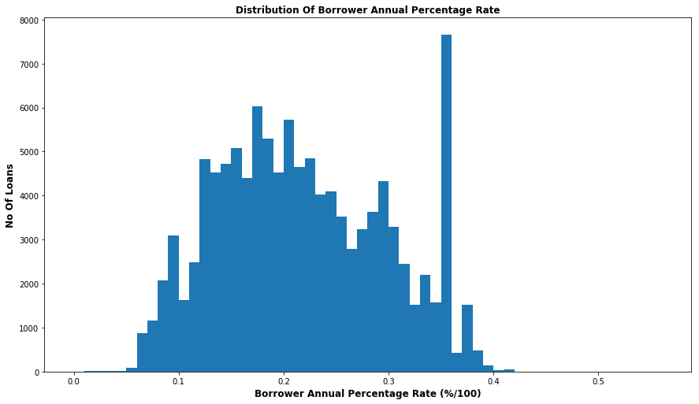

```python
#Borrower APR distribution
plt.figure(figsize=[14.70, 8.27]);
bins = np.arange(0, loan_data_subset1_copy.BorrowerAPR.max()+0.05, 0.01)

plt.hist(data = non_null_BorrowerAPR, x = 'BorrowerAPR', bins = bins);
plt.xlabel('Borrower Annual Percentage Rate (%/100)'.title(),
               fontsize = 12, weight = "bold");
plt.ylabel('No of Loans'.title(),
               fontsize = 12, weight = "bold");
plt.title('Distribution of Borrower Annual Percentage Rate'.title(),
               fontsize = 12, weight = "bold");
```

Conclusion:The distribution of Borrower APR looks slightly normally distributed with one sharp peak around 36%.

1. Debt to Income Ratio Distribution

```python
#Debt to Income Ratio distribution
loan_data_subset1_copy.DebtToIncomeRatio.describe()
```

```
count    104594.000000
mean          0.276032
std           0.553738
min           0.000000
25%           0.140000
50%           0.220000
75%           0.320000
max          10.010000
Name: DebtToIncomeRatio, dtype: float64
```

```python
non_null_DebtToIncomeRatio=loan_data_subset1_copy[loan_data_subset1_copy['DebtToIncomeRatio'].notnull()]
```

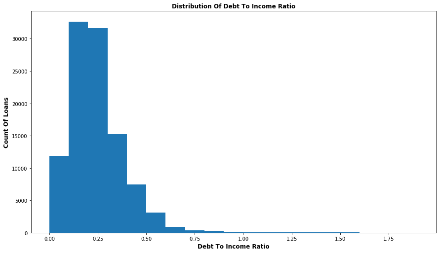

```python
plt.figure(figsize=[14.70, 8.27])
bin_loan=np.arange(0,2,0.1)
plt.hist(x=non_null_DebtToIncomeRatio['DebtToIncomeRatio'],
             bins=bin_loan);
plt.xlabel('Debt To Income Ratio'.title(),
               fontsize = 12, weight = "bold");
plt.ylabel('Count of Loans'.title(),
               fontsize = 12, weight = "bold");
plt.title('Distribution of Debt To Income Ratio'.title(),
               fontsize = 12, weight = "bold");
```

Conclusion: The distribution is right skewed with a long tail where the ratio is greater than 1.However most of the people have debt in the range of 10-30% of their income

We can further analyse the loan profiles of people who have DtoI ratio greater than 1, to see the pattern

```python
#Debt Ratio greater than 1 dataset for further analysis
DtoI_greater_than_one=loan_data_subset1_copy[loan_data_subset1_copy['DebtToIncomeRatio']>1]
len(DtoI_greater_than_one)
```

```
798
```

```python
DtoI_greater_than_one.describe()
```

|  | ListingNumber | Term | BorrowerAPR | BorrowerRate | LenderYield | EstimatedEffectiveYield | EstimatedLoss | EstimatedReturn | ProsperScore | OpenCreditLines | ... | Recommendations | InvestmentFromFriendsCount | InvestmentFromFriendsAmount | Investors | StatedMonthlyIncome | TotalProsperLoans | ProsperPrincipalBorrowed | LoanOriginalAmount | Loan_Year | EstimatedReturn_in_perct |
| --- | --- | --- | --- | --- | --- | --- | --- | --- | --- | --- | --- | --- | --- | --- | --- | --- | --- | --- | --- | --- | --- |
| count | 7.980000e+02 | 798.000000 | 798.000000 | 798.000000 | 798.000000 | 322.000000 | 322.000000 | 322.000000 | 322.000000 | 673.000000 | ... | 798.000000 | 798.000000 | 798.000000 | 798.000000 | 798.000000 | 118.000000 | 118.000000 | 798.000000 | 798.000000 | 322.000000 |
| mean | 3.392555e+05 | 37.323308 | 0.248055 | 0.227184 | 0.216389 | 0.238742 | 0.130197 | 0.120862 | 4.357143 | 9.533432 | ... | 0.132832 | 0.080201 | 64.181479 | 84.126566 | 835.385234 | 1.271186 | 5633.394915 | 6737.611529 | 2008.912281 | 12.086208 |
| std | 2.513980e+05 | 6.222413 | 0.085256 | 0.076038 | 0.075636 | 0.066971 | 0.047140 | 0.028433 | 2.038514 | 5.625926 | ... | 0.498328 | 0.398975 | 572.225280 | 92.864361 | 1495.972287 | 0.594289 | 4137.641337 | 5967.061443 | 2.476960 | 2.843327 |
| min | 3.935000e+03 | 12.000000 | 0.013250 | 0.000100 | -0.009900 | -0.083600 | 0.006000 | -0.083600 | 1.000000 | 0.000000 | ... | 0.000000 | 0.000000 | 0.000000 | 1.000000 | 0.000000 | 1.000000 | 1000.000000 | 1000.000000 | 2006.000000 | -8.360000 |
| 25% | 1.181135e+05 | 36.000000 | 0.177220 | 0.162775 | 0.152775 | 0.213400 | 0.100000 | 0.115000 | 3.000000 | 6.000000 | ... | 0.000000 | 0.000000 | 0.000000 | 21.000000 | 0.083333 | 1.000000 | 2512.750000 | 3000.000000 | 2007.000000 | 11.500000 |
| 50% | 2.368400e+05 | 36.000000 | 0.252200 | 0.233450 | 0.224800 | 0.273250 | 0.147000 | 0.120250 | 4.000000 | 8.000000 | ... | 0.000000 | 0.000000 | 0.000000 | 51.000000 | 239.416667 | 1.000000 | 4500.000000 | 4000.000000 | 2007.000000 | 12.025000 |
| 75% | 5.619498e+05 | 36.000000 | 0.332860 | 0.293200 | 0.285000 | 0.285000 | 0.157500 | 0.134700 | 6.000000 | 12.000000 | ... | 0.000000 | 0.000000 | 0.000000 | 116.000000 | 1083.333333 | 1.000000 | 7500.000000 | 9000.000000 | 2012.000000 | 13.470000 |
| max | 1.014525e+06 | 60.000000 | 0.413550 | 0.357500 | 0.345000 | 0.305700 | 0.366000 | 0.201100 | 10.000000 | 34.000000 | ... | 8.000000 | 8.000000 | 12022.320000 | 518.000000 | 17083.333333 | 4.000000 | 25000.000000 | 25000.000000 | 2013.000000 | 20.110000 |

8 rows × 23 columns

1. Distribution of Stated Monthly Income

```python
loan_data_subset1_copy.StatedMonthlyIncome.describe()
```

```
count    1.130660e+05
mean     5.605120e+03
std      7.495596e+03
min      0.000000e+00
25%      3.199396e+03
50%      4.666667e+03
75%      6.824688e+03
max      1.750003e+06
Name: StatedMonthlyIncome, dtype: float64
```

```python
loan_data_subset1_copy['StatedMonthlyIncome']=loan_data_subset1_copy['StatedMonthlyIncome'].astype(int)
```

```python
outlier_income=len(loan_data_subset1_copy[loan_data_subset1_copy['StatedMonthlyIncome']>40000])/len(loan_data_subset1_copy)
outlier_income
```

```
0.0013266587656766845
```

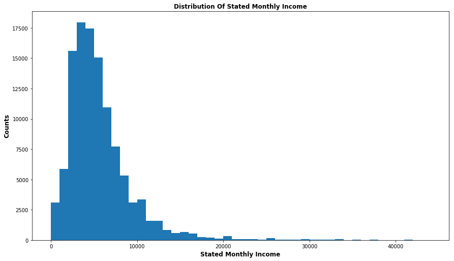

```python
plt.figure(figsize=[14.70, 8.27])
bin_edges=np.arange(0,45000,1000)
plt.hist(x=loan_data_subset1_copy['StatedMonthlyIncome'],
             bins=bin_edges);
plt.xlabel('Stated Monthly Income'.title(),
               fontsize = 12, weight = "bold");
plt.ylabel('Counts'.title(),
               fontsize = 12, weight = "bold");
plt.title('Distribution of Stated Monthly Income'.title(),
               fontsize = 12, weight = "bold");
```

Conclusion:The distribution of monthly income has right skew, with mean income around 5ooo and a long right tail extending upto 35-40 k.Only 0.1% of income was above 40k and since it was an outlier,therefore it was dropped from the distribution.

1. Distribution of Loan Statuses

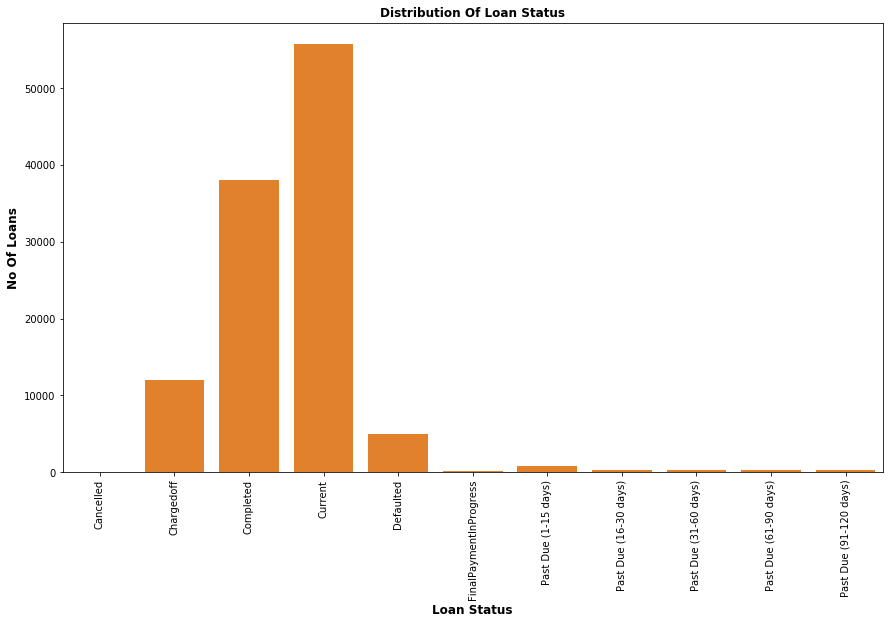

```python
#Examine the Loan Status
plt.figure(figsize=[14.70, 8.27])
base_color=sb.color_palette()[1]
sb.countplot(data=loan_data_subset1_copy,x='LoanStatus',color=base_color);
plt.xticks(rotation=90);
plt.title('Distribution of Loan Status'.title(),
               fontsize = 12, weight = "bold");
plt.ylabel('No of Loans'.title(),
               fontsize = 12, weight = "bold");
plt.xlabel('Loan Status'.title(),
               fontsize = 12, weight = "bold");
```

Conclusion: Most of the loans are current or completed. Around 12000 loans were chargedoff (due for more than 120 days) and 5000 loan were defaults

1. Number of Loans in each Credit Rating Category

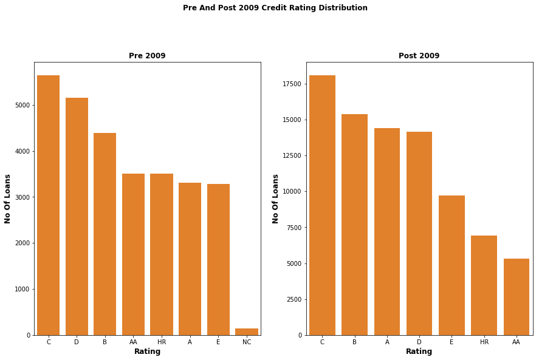

```python
# count of loans for each credit grade pre 2009
plt.figure(figsize=[14.70, 8.27]);
plt.suptitle("Pre and Post 2009 Credit Rating Distribution".title(),
               fontsize = 12, weight = "bold", y = 1.04)
plt.subplot(1,2,1)
credit_order_seq=loan_data_subset1_copy.CreditGrade.value_counts().index
credit_order_seq
sb.countplot(data=loan_data_subset1_copy,x='CreditGrade',
             color=base_color,order=credit_order_seq);
plt.title('Pre 2009'.title(),
               fontsize = 12, weight = "bold");
plt.xlabel('Rating'.title(),fontsize = 12, weight = "bold");
plt.ylabel('No of Loans'.title(),fontsize = 12, weight = "bold");


# count of loans for each credit grade after July 2009
plt.subplot(1,2,2)
credit_order_seq2=loan_data_subset1_copy['ProsperRating (Alpha)'].value_counts().index
credit_order_seq2
sb.countplot(data=loan_data_subset1_copy,x='ProsperRating (Alpha)',
             color=base_color,order=credit_order_seq2);
plt.title('Post 2009'.title(),
               fontsize = 12, weight = "bold");
plt.xlabel('Rating'.title(),fontsize = 12, weight = "bold");
plt.ylabel('No of Loans'.title(),fontsize = 12, weight = "bold");
```

A large no of loans are in the middle credit grade categories of C,D and B.The only noticeable difference between pre and post 2009 lending can be seen in the high risk category. Proportionally lending in HR category has decreased after 2009

**Discuss the distribution(s) of your variable(s) of interest. Were there any unusual points? Did you need to perform any transformations?**

1. The distribution of estimated returns looked normal. Estimated retruns had a lot of nans because this variable was only calculated for loans after July 2009, so it was cleaned.
2. The bins were carefully selected for the best possible display of distribution.

**Of the features you investigated, were there any unusual distributions? Did you perform any operations on the data to tidy, adjust, or change the form of the data? If so, why did you do this?**

When investigating the income distribution, a number of outlier points were identified.These income outliers were removed from the distribution.

## Bivariate Exploration

```python
numeric_vars = ['BorrowerAPR', 'BorrowerRate', 'EstimatedEffectiveYield', 'EstimatedReturn', 'ProsperScore', 'StatedMonthlyIncome', 'DebtToIncomeRatio']
categoric_vars = ['CreditGrade', 'ProsperRating (Alpha)', 'LoanStatus']
```

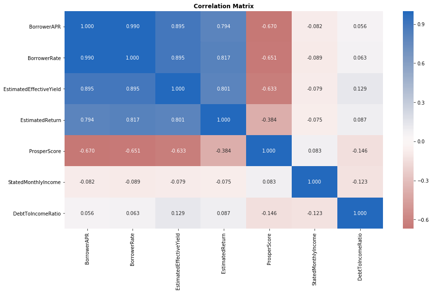

```python
# correlation plot
plt.figure(figsize=[14.70, 8.27]);
ax = plt.axes()
sb.heatmap(loan_data_subset1_copy[numeric_vars].corr(), annot = True, fmt = '.3f',
           cmap = 'vlag_r', center = 0,ax=ax)
ax.set_title('Correlation Matrix'.title(),fontsize = 12, weight = "bold");
plt.show()
```

As expected both Borrower Rate and BorrowerAPR have strong positive correlation with Estimated Return, since higher the interest rate, higher is the return. Borrower Rate is negatively correlated with Prosper Score because a higher prosper score means good credit rating and therefore lower interest rate. Borrower Rate is also negatively correlated with income because at higher levels of income, individual is likely to have a good credit rating and therefore lower interest rate. What is interesting here is Prosper Score has weak positive correlation with income and negative with Debt to income ratio.I was expecting a stronger correlation with income,because higher income means higher credit rating but apparently the score is more likely to be influenced by how much debt you have than income per se.

**QUESTIONS TO EXPLORE**

**1- How has been the growth in terms of number of loans and average size of loans over the years**

No of loans in each year, how the mean loan has varied over the years

```python
#mean loan each year
loan_data_subset1_copy.groupby('Loan_Year')['LoanOriginalAmount'].mean()
```

```
Loan_Year
2005     3855.956522
2006     4844.807500
2007     7066.793112
2008     5964.698393
2009     4393.478241
2010     4841.877396
2011     6704.403339
2012     7876.517130
2013    10604.203041
2014    11915.377969
Name: LoanOriginalAmount, dtype: float64
```

```python
#no of loans each year
loan_data_subset1_copy.groupby('Loan_Year')['ListingNumber'].count()
```

```
Loan_Year
2005       23
2006     6213
2007    11557
2008    11263
2009     2206
2010     5530
2011    11442
2012    19556
2013    34791
2014    10485
Name: ListingNumber, dtype: int64
```

```python
#No of loans in each year, how they have varied
loan_dist=loan_data_subset1_copy.groupby('Loan_Year')['LoanOriginalAmount'].count()
loans_per_year=loan_dist.reset_index(name='count')
```

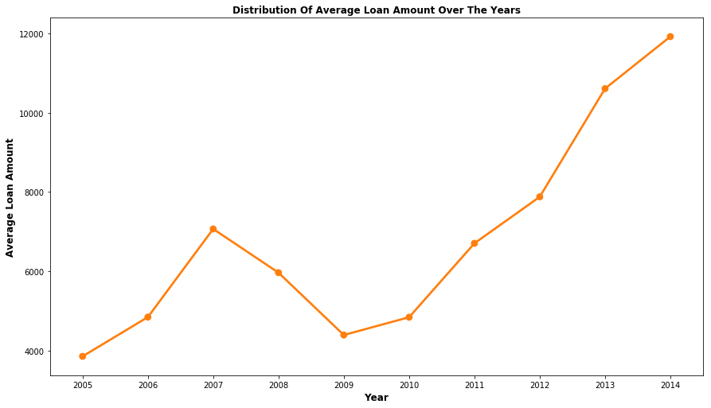

```python
#Average Loan Per Year
mean_loan=loan_data_subset1_copy.groupby('Loan_Year')['LoanOriginalAmount'].mean()
mean_loan_per_year=mean_loan.reset_index(name='mean')
plt.figure(figsize=[14.70, 8.27])
ax = plt.axes()
sb.pointplot(data=mean_loan_per_year,x='Loan_Year',y='mean',color=base_color,ax=ax);
ax.set_title('Distribution of Average Loan Amount Over The Years'.title(),fontsize = 12, weight = "bold");

plt.ylabel('Average Loan Amount'.title(),fontsize = 12, weight = "bold");
plt.xlabel('Year'.title(),fontsize = 12, weight = "bold");
```

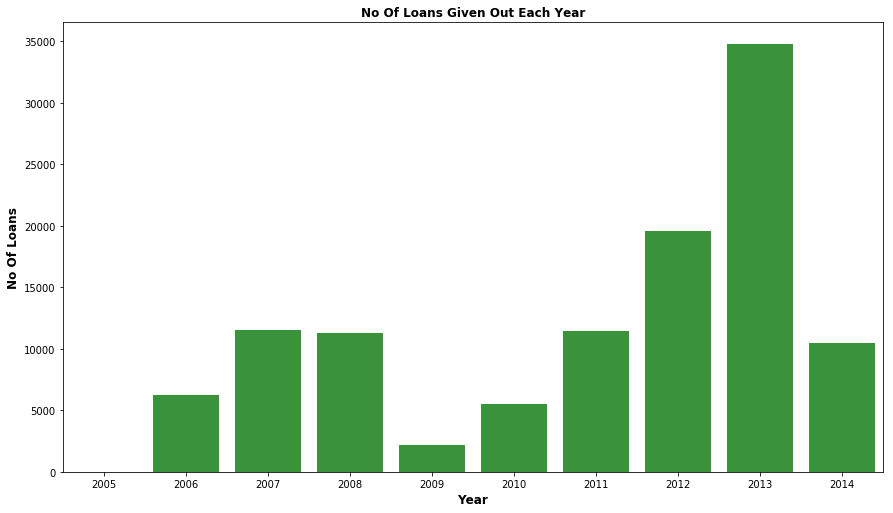

```python
#Distribution of Loan Count Per Year
plt.figure(figsize=[14.70, 8.27])
ax = plt.axes()
base_color=sb.color_palette()[2]
sb.barplot(data=loans_per_year,x='Loan_Year',y='count',color=base_color,errwidth=0,ax=ax);
ax.set_title('No of Loans given out each year'.title(),fontsize = 12, weight = "bold");

plt.ylabel('No of Loans'.title(),fontsize = 12, weight = "bold");
plt.xlabel('Year'.title(),fontsize = 12, weight = "bold");
```

Conclusion: In 2014 a sharp drop is seen because 2014 does not have the data from the whole year,it has only first two months of data. A sharp drop in number of loans and mean loans is seen in the year 2009 & 2010. This can be attributed to the 2008 financial crisis aftermath when there was a liquidity squeeze in the credit markets.

**2- With Prosper's growth in business,has it become cheaper or more expensive over the years to borrow or lend from/to Prosper**

Interest Rate & APR for borrower and Estimated Return on loans- how it has varied over the years

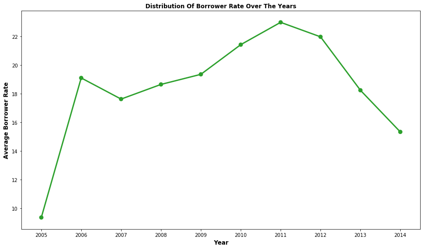

```python
#Average Borrower Rate Per Year
average_rate=loan_data_subset1_copy.groupby('Loan_Year')['BorrowerRate'].mean()
mean_borrower_rate=average_rate.reset_index(name='avg_borrower_rate')
mean_borrower_rate['avg_borrower_rate']=mean_borrower_rate['avg_borrower_rate']*100

#Average Borrower Rate Distribution
plt.figure(figsize=[14.70, 8.27])
sb.pointplot(data=mean_borrower_rate,x='Loan_Year',y='avg_borrower_rate',color=base_color)
plt.ylabel('Average Borrower Rate'.title(),fontsize = 12, weight = "bold")
plt.xlabel('Year'.title(),fontsize = 12, weight = "bold")
plt.title('Distribution of Borrower Rate over the years'.title(),fontsize = 12, weight = "bold");
```

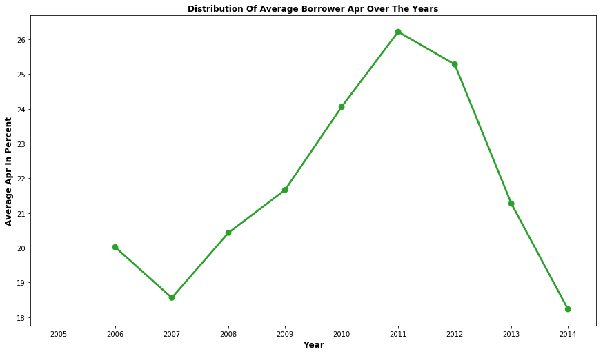

```python
#Average Borrower APR on loans per year
APR_on_loan=loan_data_subset1_copy.groupby('Loan_Year')['BorrowerAPR'].mean()
APR_on_loan=APR_on_loan.reset_index(name='avg_APR')
APR_on_loan['avg_APR']=APR_on_loan['avg_APR']*100


#Average Borrower APR on loans Distribution
plt.figure(figsize=[14.70, 8.27])
sb.pointplot(data=APR_on_loan,x='Loan_Year',y='avg_APR',color=base_color)
plt.ylabel('Average APR in Percent'.title(),fontsize = 12, weight = "bold")
plt.xlabel('Year'.title(),fontsize = 12, weight = "bold")
plt.title('Distribution of Average Borrower APR over the years'.title(),fontsize = 12, weight = "bold");
```

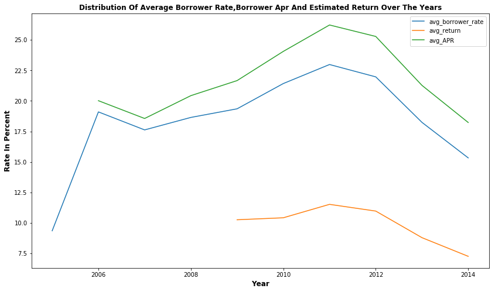

```python
#Borrower rate and return

return_on_loan=loan_data_subset1_copy.groupby('Loan_Year')['EstimatedReturn'].mean()
return_on_loan=return_on_loan.reset_index(name='avg_return')
return_on_loan['avg_return']=return_on_loan['avg_return']*100

#Distribution of borrower rate & APR and Estimated Return on loans

rate_return=pd.merge(mean_borrower_rate,return_on_loan).merge(APR_on_loan);

rate_return.plot(x='Loan_Year',figsize=(14,8));
plt.ylabel('Rate in percent'.title(),fontsize = 12, weight = "bold");
plt.title('Distribution of Average Borrower Rate,Borrower APR and Estimated Return over the years'.title(),fontsize = 12, weight = "bold");
plt.xlabel('Year'.title(),fontsize = 12, weight = "bold");
```

Conclusion: The Estimated Return is calculated only after July 2009, thats why we see the data absent over the years from 2006-2008. There is a gap (around 10% spread) between average borrower rate and estimated return on loans to investors. This spread is due to service fee charged by Prosper and any losses on loans.

**3. Are big loans cheaper or small loans more expensive?**

Examine the relationship between borrower rate and amount of loan.

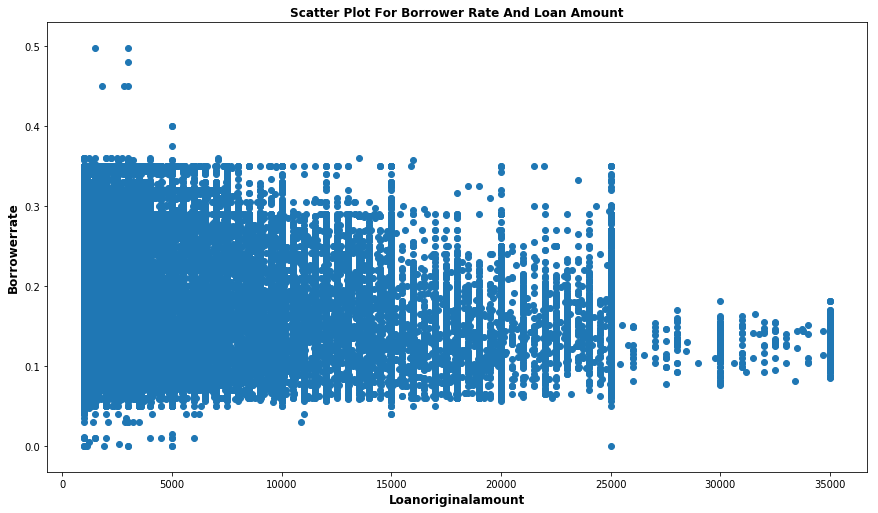

```python
#Loan amount and Borrower rate-both are quantitative variables so try scatter plot
plt.figure(figsize=[14.70, 8.27]);
plt.scatter(data=loan_data_subset1_copy,x='LoanOriginalAmount',y='BorrowerRate');
plt.xlabel('LoanOriginalAmount'.title(),fontsize = 12, weight = "bold");
plt.ylabel('BorrowerRate'.title(),fontsize = 12, weight = "bold");
plt.title('Scatter Plot for Borrower Rate and Loan Amount'.title(),fontsize = 12, weight = "bold");
```

Conclusion: This looks too messy. So I tried one of the line plots like errorbar.

The error bar is used to plot the trend of one numeric variable against values of a second variable. In contrast to a scatterplot, where all data points are plotted, in an errorbar only one point is plotted for every unique x-value or bin of x-values (like a histogram). If there are multiple observations in an x-bin, then the y-value of the point plotted in the line plot will be a summary statistic(like mean or median) of the data in the bin.

```python
loan_data_subset1_copy.LoanOriginalAmount.describe()
```

```
count    113066.000000
mean       8314.762307
std        6237.007841
min        1000.000000
25%        4000.000000
50%        6300.000000
75%       12000.000000
max       35000.000000
Name: LoanOriginalAmount, dtype: float64
```

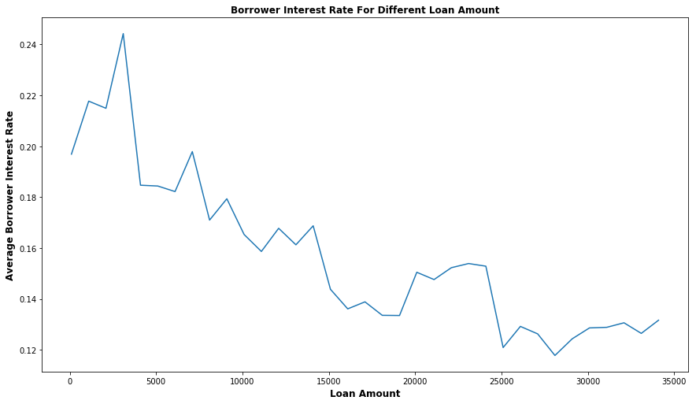

```python
#Error bar to plot the average borrower rate for different loan sizes
plt.figure(figsize=[14.70, 8.27]);
bins_edges=np.arange(0,36000,1000)
bins_c=bins_edges[:-1]+100
loan_bucket=pd.cut(loan_data_subset1_copy.LoanOriginalAmount,bins_edges,include_lowest=True)

average_borrower_rate=loan_data_subset1_copy.BorrowerRate.groupby(loan_bucket).mean()
#average_borrower_rate
plt.errorbar(x=bins_c,y=average_borrower_rate);
plt.xlabel('Loan Amount'.title(),fontsize = 12, weight = "bold")
plt.ylabel('Average Borrower Interest Rate'.title(),fontsize = 12, weight = "bold")
plt.title('Borrower Interest Rate for different Loan Amount'.title(),fontsize = 12, weight = "bold");
```

A further investigation into the data brings out the fact that this is due to high credit rating loans which dominate the high amount loans.These high credit rating loans have lower borrower rate therefore interest rate decline with higher amount.

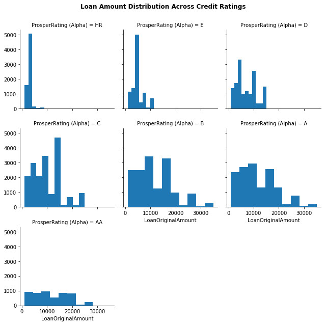

```python
# How the loan amounts have varied across different credit ratings

g = sb.FacetGrid(data = loan_data_subset1_copy, col = 'ProsperRating (Alpha)', col_wrap = 3)
g.map(plt.hist,'LoanOriginalAmount');
#g.set_title('Loan Amount Distribution Across Credit Ratings');
plt.subplots_adjust(top=0.9)
g.fig.suptitle('Loan Amount Distribution Across Credit Ratings'.title(),fontsize = 12, weight = "bold");
```

Conclusion: Good Credit ratings have a wider loan distribution across all loan amounts while bad credit ratings have loan distributions skewed towards smaller loan amounts. This analysis is linked with the question below

**4- What was the nature of lending to high risk borrowers in terms of loan amounts**

Examine the distribution of loan amounts in different credit grades

There were too many categories of credit ratings and too many bins for loan amounts. There fore I streamlined both these categories into 3 divisions each; Ratings were divided on the basis of credit riskiness as high, medium and low credit risk and loan amounts were sliced into 3 types of small, medium and large loans

```python
#Loan between 5 & 10 k
small_amount_loan=loan_data_subset1_copy[(loan_data_subset1_copy['LoanOriginalAmount']>5000) & (loan_data_subset1_copy['LoanOriginalAmount']<10001)]['ProsperRating (Alpha)']
small_amount_loan.value_counts()


#create a dataframe
df_small=small_amount_loan.value_counts().reset_index(name='small_loan_count')
df_small['small_loan_percent']=df_small['small_loan_count']*100/df_small['small_loan_count'].sum()


##Loan between 10 & 20 k
medium_amount_loan=loan_data_subset1_copy[(loan_data_subset1_copy['LoanOriginalAmount']>10000) & (loan_data_subset1_copy['LoanOriginalAmount']<20001)]['ProsperRating (Alpha)']
medium_amount_loan.value_counts()

#create a dataframe
df_medium=medium_amount_loan.value_counts().reset_index(name='medium_loan_count')
df_medium['medium_loan_percent']=df_medium['medium_loan_count']*100/df_medium['medium_loan_count'].sum()


#loan amount more than 20k
large_amount_loan=loan_data_subset1_copy[loan_data_subset1_copy['LoanOriginalAmount']>20000]['ProsperRating (Alpha)']
large_amount_loan.value_counts()

#create a dataframe
df_large=large_amount_loan.value_counts().reset_index(name='large_loan_count')
df_large['large_loan_percent']=df_large['large_loan_count']*100/df_large['large_loan_count'].sum()
```

```python
#merge the three dataframes
loan_amounts_df=df_small.merge(df_medium,on='index')
loan_amounts_df=loan_amounts_df.merge(df_large,on='index')
loan_amounts_df

#transpose the columns and rows
loan_amounts_df=loan_amounts_df.transpose()
loan_amounts_df

#drop index & change column names
loan_amounts_df.columns=['C','D','B','A','E','AA','HR']
loan_amounts_df=loan_amounts_df.drop('index')
```

```python
#merge the 7 credit grades into 3 categories of high, medium and low risk
loan_amounts_df['high_risk']=loan_amounts_df['HR']+loan_amounts_df['E']
loan_amounts_df['medium_risk']=loan_amounts_df['C']+loan_amounts_df['D']
loan_amounts_df['low_risk']=loan_amounts_df['AA']+loan_amounts_df['A']+loan_amounts_df['B']

#Drop unwanted columns
loan_amounts_df=loan_amounts_df.drop(columns=['C','D','B','A','E','AA','HR'])
```

```python
loan_amounts_df
```

|  | high_risk | medium_risk | low_risk |
| --- | --- | --- | --- |
| small_loan_count | 2357 | 11235 | 10330 |
| small_loan_percent | 9.85286 | 46.9651 | 43.182 |
| medium_loan_count | 10 | 8715 | 13586 |
| medium_loan_percent | 0.0448209 | 39.0614 | 60.8937 |
| large_loan_count | 0 | 1041 | 3037 |
| large_loan_percent | 0 | 25.5272 | 74.4728 |

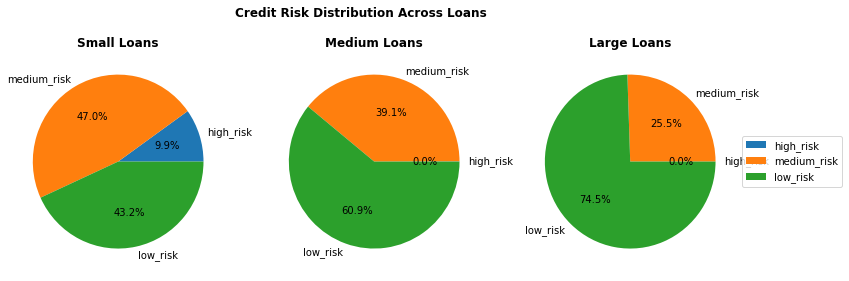

```python
#show how the credit grades vary across different loan sizes
plt.figure(figsize = [13, 4])
plt.tight_layout();
plt.suptitle("Credit Risk Distribution Across Loans ".title(),fontsize = 12, weight = "bold", y = 1.04)
plt.subplot(1,3,1)

plt.pie(loan_amounts_df.loc['small_loan_percent'],labels=loan_amounts_df.columns,autopct='%1.1f%%');
plt.title('Small loans'.title(),fontsize = 12, weight = "bold")
plt.subplot(1,3,2)
plt.pie(loan_amounts_df.loc['medium_loan_percent'],labels=loan_amounts_df.columns,autopct='%1.1f%%');
plt.title('Medium loans'.title(),fontsize = 12, weight = "bold")
plt.subplot(1,3,3)
plt.pie(loan_amounts_df.loc['large_loan_percent'],labels=loan_amounts_df.columns,autopct='%1.1f%%');
plt.title('Large loans'.title(),fontsize = 12, weight = "bold")
plt.legend(loc='center left',bbox_to_anchor=(1, 0.5));
```

Conclusion: 75% of large loans are given to low risk categories, while only 25% is given to medium risk. No loans are given in high risk categories. Even medium loans are also not given to high risk categories.Only small loans are given to high risk categories.

This explains why borrower interest rate declines with increasing amount of loans, since only low risk borrowers get those loans, and low risk borrowers also have low borrower rate

**5- Prosper had changed how it determined the borrower rate in 2009, from the earlier Dutch auction style method to algorithm determined borrower rate. How has the borrower rate changed over these two periods-pre 2009 & post 2009**

```python
#pre 2009 borrower interest rate distribution across credit grades
average_interest_rate_for_each_credit_grade_pre_2009=loan_data_subset1_copy.BorrowerRate.groupby(loan_data_subset1_copy['CreditGrade']).mean()

#post 2009 borrower interest rate distribution across credit grades
average_interest_rate_for_each_credit_grade_after_2009=loan_data_subset1_copy.BorrowerRate.groupby(loan_data_subset1_copy['ProsperRating (Alpha)']).mean()
```

```python
#reset index
average_interest_rate_for_each_credit_grade_pre_2009=average_interest_rate_for_each_credit_grade_pre_2009.reset_index(name='pre_2009rate')
#remove NC category
average_interest_rate_for_each_credit_grade_pre_2009=average_interest_rate_for_each_credit_grade_pre_2009[average_interest_rate_for_each_credit_grade_pre_2009['CreditGrade'] != 'NC']
average_interest_rate_for_each_credit_grade_pre_2009
#rename column name
average_interest_rate_for_each_credit_grade_pre_2009=average_interest_rate_for_each_credit_grade_pre_2009.rename(columns={"CreditGrade" : "rating"})
```

```python
#reset index & rename column name for post 2009
average_interest_rate_for_each_credit_grade_after_2009=average_interest_rate_for_each_credit_grade_after_2009.reset_index(name='post_2009rate')
average_interest_rate_for_each_credit_grade_after_2009=average_interest_rate_for_each_credit_grade_after_2009.rename(columns={"ProsperRating (Alpha)": "rating"})
```

```python
#merge the two dataframes
before_after_df=pd.merge(average_interest_rate_for_each_credit_grade_pre_2009,average_interest_rate_for_each_credit_grade_after_2009)
before_after_df
```

|  | rating | pre_2009rate | post_2009rate |
| --- | --- | --- | --- |
| 0 | HR | 0.255509 | 0.317352 |
| 1 | E | 0.255756 | 0.293509 |
| 2 | D | 0.211915 | 0.246590 |
| 3 | C | 0.179671 | 0.194614 |
| 4 | B | 0.153568 | 0.154608 |
| 5 | A | 0.125080 | 0.112959 |
| 6 | AA | 0.098063 | 0.079139 |

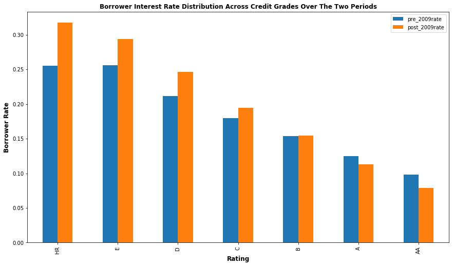

```python
plt.figure(figsize=[14.70, 8.27])
before_after_df.plot(kind='bar',x='rating',figsize=(14.70, 8.27));
plt.ylabel('Borrower Rate'.title(),fontsize = 12, weight = "bold");
plt.xlabel('Rating'.title(),fontsize = 12, weight = "bold");
plt.title('Borrower Interest Rate Distribution across Credit Grades over the two periods'.title(),fontsize = 12, weight = "bold");
```

Conclusion: High risk borrowing has become expensive and low risk borrowing has become cheaper after algorithm determined borrower rate were introduced. After 2009 the rates have increased for lower credit rating ( HR,E,D,C) categories but decreased for higher credit ratings (A & AA)

**Talk about some of the relationships you observed in this part of the investigation. How did the feature(s) of interest vary with other features in the dataset?**

**Did you observe any interesting relationships between the other features (not the main feature(s) of interest)?**

High risk borrowing has become expensive and low risk borrowing has become cheaper after algorithm determined borrower rate were introduced. After 2009 the rates have increased for lower credit rating ( HR,E,D,C) categories but decreased for higher credit ratings (A & AA)

## Multivariate Exploration

**Points to explore**

- See how the estimated return and borrower rate varies across different credit ratings
- Check for the default percentage across different ratings
- See how the borrower rate varies with credit rating for different terms of loans
- See how the borrower rate varies with credit rating and home ownership status.

```python
#estimated return and borrower rate variation across different credit ratings
graph=loan_data_subset1_copy.groupby(['ProsperRating (Alpha)'])['BorrowerRate','EstimatedReturn'].mean()
graph=graph.reset_index()
graph['BorrowerRate'] = graph['BorrowerRate']*100
graph['EstimatedReturn']=graph['EstimatedReturn']*100
```

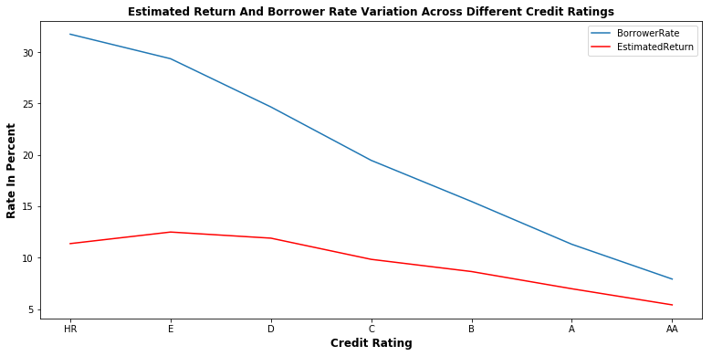

```python
#estimated return and borrower rate variation across different credit ratings
#plot the graph
names=['HR','E','D','C','B','A','AA']
plt.figure(figsize = [13, 6])
ax = plt.gca()
graph.plot(kind='line',x='ProsperRating (Alpha)',y='BorrowerRate',ax=ax)
graph.plot(kind='line',x='ProsperRating (Alpha)',y='EstimatedReturn', color='red', ax=ax,title='Borrower Rate and Estimated Return per Credit Rating')
plt.xticks(np.arange(0,7,1),names);
ax.set_title('Estimated Return and Borrower Rate Variation Across Different Credit Ratings'.title(),fontsize = 12, weight = "bold");
plt.xlabel('Credit Rating'.title(),fontsize = 12, weight = "bold");
plt.ylabel('Rate in Percent'.title(),fontsize = 12, weight = "bold");
plt.show();
```

Conclusion:We can see that borrower rate has a higher variation compared to the Estimated return.The return goes down as credit risk decreases, however the rate of dcrease in return is not as much as rate of decrease in interest rate for borrower. Borrower interest rate declines sharply as credit risk decreases as opposed to Estimated Returns that declins more gradually.Why is the spread between borrower rate and estimated return so high with high credit risk categories than with low credit risk categories. This may be because of loan defaults and chargedoffs which are higher for high credit risk categories.We need to find out

```python
#Loan Defaults
defaulted_loans=loan_data_subset1_copy[loan_data_subset1_copy.LoanStatus =='Defaulted']
defaults=defaulted_loans.groupby('ProsperRating (Alpha)')['ListingNumber'].count()
defaults=defaults.reset_index()
defaults=defaults.rename(columns={'ListingNumber':'default_loans'})
#defaults

#loans_in_each_rating
loans_in_each_rating=loan_data_subset1_copy.groupby('ProsperRating (Alpha)')['ListingNumber'].count()
loans_in_each_rating=loans_in_each_rating.reset_index()
loans_in_each_rating=loans_in_each_rating.rename(columns={'ListingNumber':'total_loans'})
```

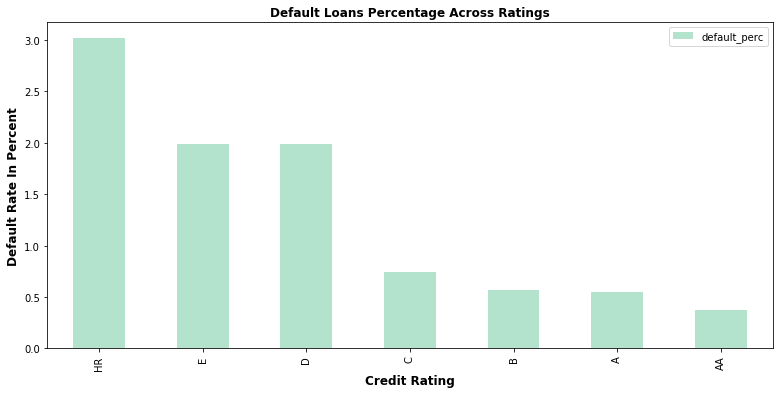

```python
#plot rating_wise_defaults

rating_wise_defaults=pd.merge(defaults,loans_in_each_rating,on='ProsperRating (Alpha)')
rating_wise_defaults['default_perc']=rating_wise_defaults['default_loans']*100/rating_wise_defaults['total_loans']
rating_wise_defaults.plot(kind='bar',x='ProsperRating (Alpha)',
                          y='default_perc',colormap='Pastel2',figsize=(13, 6));
plt.xlabel('Credit Rating'.title(),fontsize = 12, weight = "bold");
plt.ylabel('Default Rate in Percent'.title(),fontsize = 12, weight = "bold");

plt.title('Default Loans Percentage Across Ratings'.title(),fontsize = 12, weight = "bold");
```

Conclusion: The loan default percentage does not look very high to justify the spread that exists between borrower rate and estimated return. We need to dig deeper to check if the chargedoff loans (loans due for more than 120 days), whom we call Non Performing Assets are also contributing to this gap.

```python
#Chargedoff Loans
chargedoff_loans=loan_data_subset1_copy[loan_data_subset1_copy.LoanStatus =='Chargedoff']
chargedoffs=chargedoff_loans.groupby('ProsperRating (Alpha)')['ListingNumber'].count()
chargedoffs=chargedoffs.reset_index()
chargedoffs=chargedoffs.rename(columns={'ListingNumber':'chargedoffs_loans'})
chargedoffs
```

|  | ProsperRating (Alpha) | chargedoffs_loans |
| --- | --- | --- |
| 0 | HR | 1215 |
| 1 | E | 1131 |
| 2 | D | 1395 |
| 3 | C | 706 |
| 4 | B | 500 |
| 5 | A | 326 |
| 6 | AA | 63 |

```python
#total chargedoff plus defaulted loans
bad_loans=pd.merge(rating_wise_defaults,chargedoffs,on='ProsperRating (Alpha)')
bad_loans['NPAs']=bad_loans['default_loans']+bad_loans['chargedoffs_loans']
bad_loans['NPAs_perc']=bad_loans['NPAs']*100/bad_loans['total_loans']
bad_loans
```

|  | ProsperRating (Alpha) | default_loans | total_loans | default_perc | chargedoffs_loans | NPAs | NPAs_perc |
| --- | --- | --- | --- | --- | --- | --- | --- |
| 0 | HR | 209 | 6917 | 3.021541 | 1215 | 1424 | 20.586960 |
| 1 | E | 193 | 9716 | 1.986414 | 1131 | 1324 | 13.627007 |
| 2 | D | 282 | 14170 | 1.990120 | 1395 | 1677 | 11.834862 |
| 3 | C | 134 | 18096 | 0.740495 | 706 | 840 | 4.641910 |
| 4 | B | 88 | 15368 | 0.572618 | 500 | 588 | 3.826132 |
| 5 | A | 79 | 14390 | 0.548992 | 326 | 405 | 2.814454 |
| 6 | AA | 20 | 5325 | 0.375587 | 63 | 83 | 1.558685 |

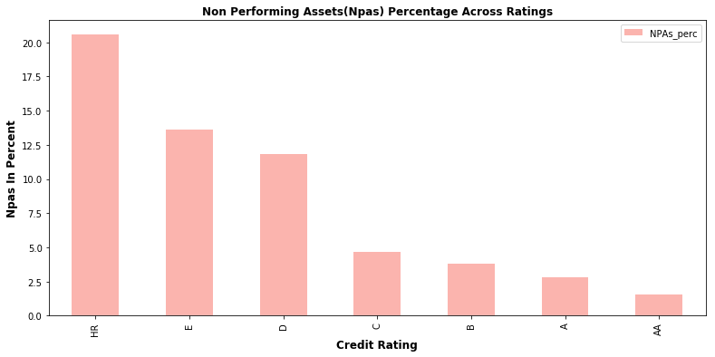

```python
#NPAs plot
bad_loans.plot(kind='bar',x='ProsperRating (Alpha)',
               y='NPAs_perc',colormap='Pastel1',figsize=(13,6)
               );
plt.xlabel('Credit Rating'.title(),fontsize = 12, weight = "bold");
plt.ylabel('NPAs in Percent'.title(),fontsize = 12, weight = "bold");

plt.title('Non Performing Assets(NPAs) Percentage Across Ratings'.title(),fontsize = 12, weight = "bold");
```

Conclusion: We see how the percentage rises so sharply as soon as we include the chargedoff loans. This explains why there is such a big spread between borrower rate and estimated return at high risk categories.It is because NPAs in HR amounts to about 20% of total loans while in low risk categories its as little as 2%

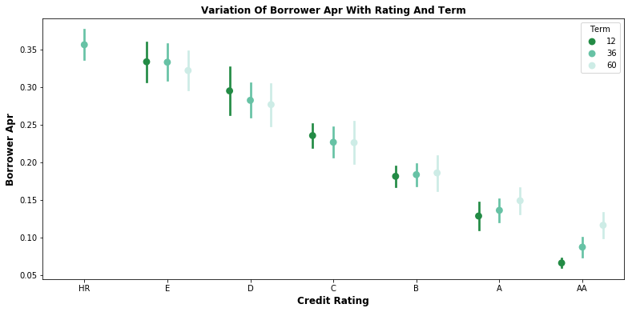

```python
# borrower rate variation with credit rating for different terms of loans
fig = plt.figure(figsize = [13,6])
ax = sb.pointplot(data = loan_data_subset1_copy, x = 'ProsperRating (Alpha)', y = 'BorrowerAPR', hue = 'Term',
           palette = 'BuGn_r',linestyles = '', dodge = 0.5, ci='sd')
plt.title('Variation of Borrower APR with Rating and Term'.title(),fontsize = 12, weight = "bold")
plt.ylabel('Borrower APR'.title(),fontsize = 12, weight = "bold")
plt.xlabel('Credit Rating'.title(),fontsize = 12, weight = "bold")

ax.set_yticklabels([],minor = True);
```

Conclusion:For the same credit category short term loans are cheaper compared to long term loans for low risk categories(AA,A,B).As Credit Risk increases this trend reverses and long term loans are cheaper than short term loans(C,D,E).

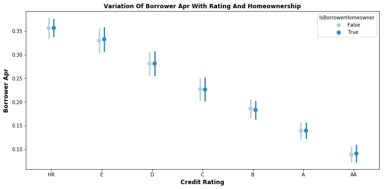

```python
#borrower rate variation with credit rating and home ownership status.
fig = plt.figure(figsize = [13,6])
ax = sb.pointplot(data = loan_data_subset1_copy, x = 'ProsperRating (Alpha)', y = 'BorrowerAPR', hue = 'IsBorrowerHomeowner',
           palette = 'Blues',linestyles = '', dodge = 0.1, ci='sd');
plt.title('Variation of Borrower APR with Rating and Homeownership'.title(),fontsize = 12, weight = "bold");
plt.ylabel('Borrower APR'.title(),fontsize = 12, weight = "bold");
plt.xlabel('Credit Rating'.title(),fontsize = 12, weight = "bold");

ax.set_yticklabels([],minor = True);
```

Conclusion: From the graph it doesn't look like there is any difference on rates because of home ownership.

**Talk about some of the relationships you observed in this part of the investigation. Were there features that strengthened each other in terms of looking at your feature(s) of interest?**

So in Bivariate Analysis we found out how borrower rate varied with credit rating and loan amounts. In this section we studied the spread between borrower rate and estimated return for different credit ratings. We found that there was very high spread between borrower rate and return for High Risk categories. We initially suspected it to be because of defaulted loans but we found that defaults were only 3% of total loans in HR category. This couldn't explain this big a spread, so we looked at chargedoff loans. This explained the spread because when we include both defaults and chargedoff loans the percentage of bad loans shoots up to 20% ie 1 in every 5 loan is bad, which explains why the spread is so high- and that is because the risk is so high.

**Were there any interesting or surprising interactions between features?**

For the same credit category short term loans are cheaper compared to long term loans for low risk categories(AA,A,B).This is intuitive as you expect the risk to increase as term increases for loans.However this trend reverses for high risk categories.As Credit Risk increases long term loans become cheaper than short term loans(C,D,E).